# STA304

2016-03-14

## ratio, regression, difference estimation

## recap

If one has a sample \(\{(y_1,x_1),\ldots,(y_n,x_n)\}\) the following may be of interest:

1. To estimate the population ratio \(R = \tau_y\big/\tau_x\) using \(\hat R=r={\overline{y}}\big/{\overline{x}}\).
2. To enable estimation of \(\tau_y\) when \(N\) is unknown.
3. To enable improved estimation of \(\tau_y\) or \(\mu_y\) when \(y\) and \(x\) are correlated.

Formula summary:

| \(r\) | \(\hat\tau_y\) | \(\hat\mu_y\) | \(\hat V(r)\) |
| --- | --- | --- | --- |
| \({\overline{y}}\big/{\overline{x}}\) | \(r\tau_x\) | \(r\mu_x\) | \(s^2_r\) |

The error bounds are based on this new object:\[s^2_r = \frac{\sum_{i=1}^n (y_i - r x_i )^2}{n-1}\]

## \(r_i = y_i - r x_i\) is a "residual"

Reconsider the teacher salary example with \(r = 1.0380283\). First 5 lines shown:

```
##   Teacher  Past Present Predicted = r*Past        r_i
## 1       1 30400   31500           31556.06  -56.06028
## 2       2 31700   32600           32905.50 -305.49706
## 3       3 32792   33920           34039.02 -119.02397
## 4       4 34956   36400           36285.32  114.68280
## 5       5 31355   32020           32547.38 -527.37730
```

Think of \(rx_i\) as the "predicted" value for \(y_i\). Then \(y_i - rx_i\) is in some sense a prediction error, or "residual". And \(s^2_r\) is just the "average" of the squared residuals.

## "residuals" plotted

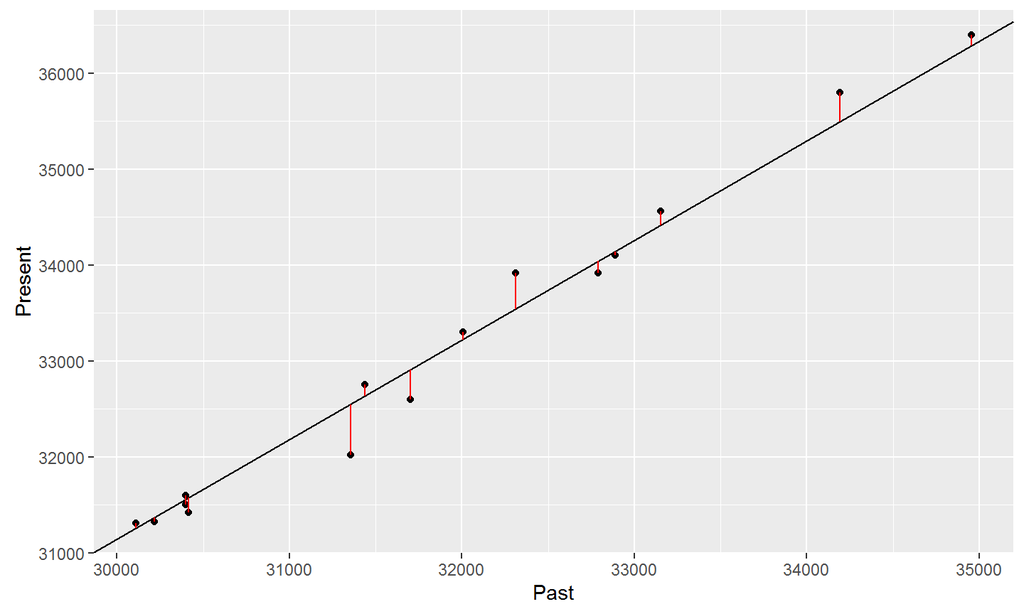

## example of improved estimation

We have estimated a ratio and estimated \(\tau_y\) using ratio techniques because there was no other option. In this example we'll estimate \(\mu_y\) using ratio techniques simply to take advantage of the information contained in the \(x\) variable.

Consider question 6.6. "Rats doing mazes while on drugs". They have $N = 763 who completed the maze on the standard drug in an average of \(\mu_x=17.2\) seconds.

A random sample of 11 rats are given a new drug. Their old times \(x_i\) were known from before and they complete the maze while on the new drug in time \(y_i\).

The task is to estimate the average maze time \(\mu_y\) for the new drug.

## these are your rats on drugs

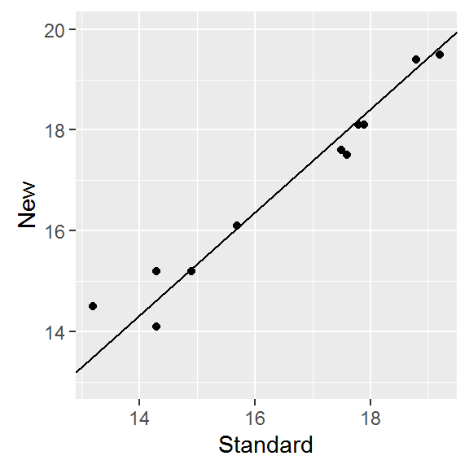

\(s^2_r = 0.2049424\).